# Project 6: Show of Hands Analysis

Tim Hagemeister

21 November, 2019

# The Data

The dataset for this lab (download here) contains the responses from 3,906 American users of the “Show of Hands” app for iPhone and Android. On the app, users answer questions about a variety of socioeconomic questions ranging from gender, income, and political party to more esoteric questions like “Does life have a purpose?” or “Are you left-handed?”.

# The Lab

In this lab, we’ll be using all we know about inference to study political party affiliation of users of the Show of Hands app. You might find it helpful to refer to your code from Lab 5; there are similarities here. For all inference tools used (i.e., hyp tests and CIs), be sure to include full discussion of the process, detailed interpretation of the results, and any concerns about the validity of the conclusion one might have. Use this lab as an opportunity to demonstrate your understanding of hyp tests and CIs in a practical setting. We’ll consider this dataset to be a sample of the larger population of Show of Hands users. Your job will to be to write up a polished analysis (with intro and conclusion) that addresses the following issues:

## Part 1: The Whole Sample

What can you say about the political party for the entire dataset? What are the sample proportions for Democrats and Republicans; which party is in the majority in this sample?

Use a hypothesis test to see if there’s statistically significant evidence that a higher proportion of users belong to the majority party (i.e., greater than 50%). Carefully explain all steps, and the implications of your conclusion. What conditions are required for the sample in order to perform such a hypothesis test; are these conditions met by your sample?

Also, construct and interpret a confidence interval for the proportion of users that belong to the majority party. Does this CI agree with the results of your test? Why or why not? What is the margin of error for that confidence interval? How large would our sample have needed to be in order to get estmate the proportion to within 1% (i.e., MOE of 1%?)

### Analysis

Within the whole dataset there are a total of 2,081 Democrats and 1,825 Republicans. This amkes the majority of the people Democrats with a ratio of 1.14:1 Democrats to Republicans. Another way to phrase this is that in the whole sample that we have, 53.28% of them are Democrats

#### Confidance Interval for our popoulation:

```r
propd <- sum(PolData$Party == "Democrat")/nrow(PolData)
phatd <-sum(PolData$Party == "Democrat")/3906



## Democrat
lower50d <- phatd - 0.67449*sqrt(phatd*(1-phatd)/3906)
upper50d <- phatd + 0.67449*sqrt(phatd*(1-phatd)/3906)
lower95d <- phatd - 1.96*sqrt(phatd*(1-phatd)/3906)
upper95d <- phatd + 1.96*sqrt(phatd*(1-phatd)/3906)
lower99d <- phatd - 2.576*sqrt(phatd*(1-phatd)/3906)
upper99d <- phatd + 2.576*sqrt(phatd*(1-phatd)/3906)


CI50d <- c("Democrat 50% CI", round(lower50d,3), round(upper50d,3), round(propd, 3))
CI95d <- c("Democrat 95% CI", round(lower95d,3), round(upper95d,3), round(propd, 3))
CI99d <- c("Democrat 99% CI", round(lower99d,3), round(upper99d,3), round(propd, 3))
```

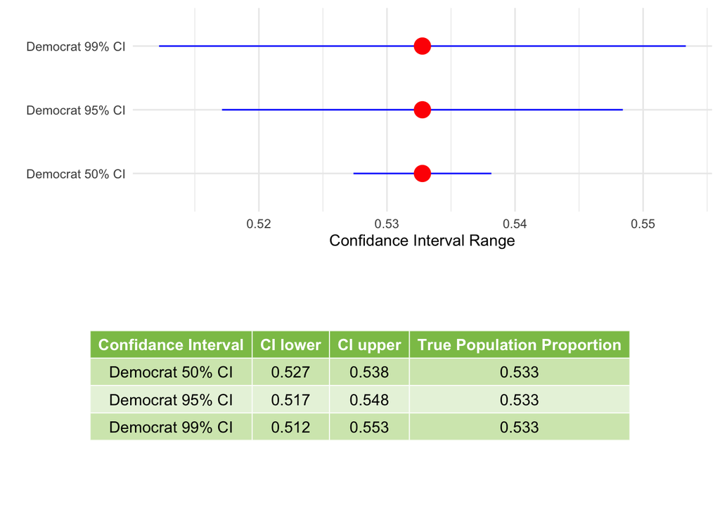

```r
ggarrange(chart1,table1,
          nrow=2,
          heights = c(2, 2))+
  ggtitle("Show of Hands (Democrats)")
```

**What does this tell us ?**

**How large would our sample have needed to be in order to get the estimate proportion to within 1%.**

Since MOE = zstar x sqrt(p(1-p)/n), we can find n using the following equation to find out sampel zise needed to have a margin of error of 1% $n = p(1-p)*(zstar/MOE)^2$ - We would need a sample size of **9,570** people for us to have a Margin of Error of 1% and a Confidance Interval of 95%

## Part 2: Educational Subgroup Analysis

Now, pick two educational groups that you’d like to compare. What are the majority parties in those two groups? For each group, use CIs to estimate the proportion who belong to the majority party. What conclusions do you make about the two groups based on these estimates?

Conduct a 2-sample Z test for proportions to investigate evidence for a difference between the two groups. Carefully explain all steps and conclusions.

Explain carefully what Type I and Type II errors would mean in this case. Which one is worse, do you think? Ceratinly, you could argue either way here: your reasoning is the important part, not which error you think is worse. Based on your reasoning, what adjustments might you make to the hyp test?

Construct a CI to estimate the difference in proportion of party affiliation between the two groups. Discuss the conclusion, the connection to the hyp test above, and the margin of error.

We will be comparing Current Undergraduate students and High School Students Democratic Affiliation, I think that this is a reasonable comparison as we as current undergraduates went trough this transition and think differenetly now that we are in college. I hope to see a difference in these results.

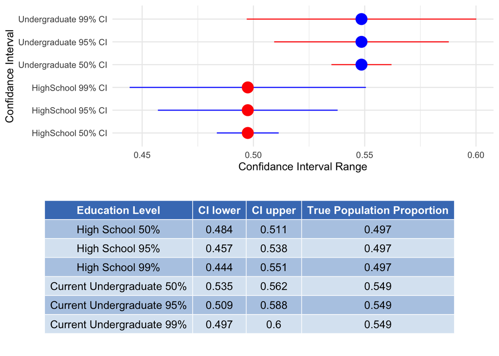

```r
ggarrange(chart2,table2,
          nrow=2,
          heights = c(2, 2))+
  ggtitle("Show of Hands High School vs. Undergraduate (Democrats)")
```

**What does this tell us**

Based on this information we can conlcude if the majority party of the two groups. For Highschoolers, we are unable to say which one is in the majority as the 95% CI is right aorund the 50% line. However for Undergrduates, we are able to estimate with a fair amount of proof Democrats are in the majority.

### Hypothesis test Between Educational Groups Democratic Affiliation

1. Hypothesis: During this test, we are able to compare two different groups and see if they proove to be in a majority or not.
- H0: p1 - p2 = 0 (assume no difference)
- Ha: p1 $\ne$ p2
2. Test Statistic Using the following formula
   $$(zscore = (\hat{p1}-\hat{p2}) / \sqrt{\hat{pooled}((1-\hat{pooled})/n1)+\hat{pooled}((1-\hat{pooled})/n2)})$$
   we are able to find the z-score which will give us a understanding of the actual population of democrats.
3. P - Value
   - We get a p value of 0.07565932. This is not a significant difference and therefore we fail to reject H0. However it is close to being significant, although this does not alter our conclusion of failing to reject H0, it is an interesting observation.

### Types of error

- Type 1 error would be that we say that they are different when in reality they are not different
- Type 2 error would be that we say that they are not different when in reality they are different
- In my opinion, I think that type 1 error would be worse, this is becasue i think saying there is a difference might put a wedge into these different groups when a type 1 error might bring different groups closer together if they think that they are not different. We want a smaller Alpha and a bigger beta.

## Checking Conditions.

Before we conduct these tests or construct intervals, we always need to check: are we justified in using a normal dist?

np > 10 and n(1-p)> 10

**After running the different test, we can conclude that these conditions are justified in using a normal distribution.**

```r
#HS Democrats
phat1 <-  293/589
#UG Democrats
phat2 <- 339/618

#n for HS
n1 <- 589
#n for UG
n2 <- 618
```

## Limitations

There are some limitations to our data however. Since this data is self reported, we need to take into considerration that not everyone wants to publicly register their affiliation on a app. We should always be cautuous about conclusions about our data.